# Missingness_Imputation_Homework

Alex Baransky

## Question #1: Missingness & Imputation for the Titanic Dataset

Load the `titanic3` dataset from the `PASWR` library; this dataset describes the survival status of individual passengers from the Titanic voyage. There are 14 different variables, some of which have quite a bit of missingness.

1. How many variables contain at least one missing value?
   - What are these variables?
   - For each variable, what is the extent of missingness (how many missing values are there and what is the percentage of missingness)?

```r
library(PASWR)
data("titanic3")

titanic3[titanic3 == ''] = NA
colnames(titanic3)[colSums(is.na(titanic3)) > 0]
```

```
## [1] "age"       "fare"      "cabin"     "embarked"  "boat"      "body"
## [7] "home.dest"
```

```r
sum(is.na(titanic3$age))
```

```
## [1] 263
```

```r
sum(is.na(titanic3$age))/length(titanic3$age)
```

```
## [1] 0.2009167
```

```r
sum(is.na(titanic3$fare))
```

```
## [1] 1
```

```r
sum(is.na(titanic3$fare))/length(titanic3$fare)
```

```
## [1] 0.0007639419
```

```r
sum(is.na(titanic3$cabin))
```

```
## [1] 1014
```

```r
sum(is.na(titanic3$cabin))/length(titanic3$cabin)
```

```
## [1] 0.7746371
```

```r
sum(is.na(titanic3$embarked))
```

```
## [1] 2
```

```r
sum(is.na(titanic3$embarked))/length(titanic3$embarked)
```

```
## [1] 0.001527884
```

```r
sum(is.na(titanic3$boat))
```

```
## [1] 823
```

```r
sum(is.na(titanic3$boat))/length(titanic3$boat)
```

```
## [1] 0.6287242
```

```r
sum(is.na(titanic3$body))
```

```
## [1] 1188
```

```r
sum(is.na(titanic3$body))/length(titanic3$body)
```

```
## [1] 0.907563
```

```r
sum(is.na(titanic3$home.dest))
```

```
## [1] 564
```

```r
sum(is.na(titanic3$home.dest))/length(titanic3$home.dest)
```

```
## [1] 0.4308633
```

2. How many observations contain at least one missing value?
   - What is the percentage of missingness from an observation standpoint? (Hint: the complete.cases() function might be useful here).

```r
sum(rowSums(is.na(titanic3)) > 0)
```

```
## [1] 1309
```

```r
nrow(titanic3[!complete.cases(titanic3),])/nrow(titanic3)
```

```
## [1] 1
```

3. How many cells in the data are missing values?
   - What is the percentage of missingness from a dataset standpoint?

```r
sum(is.na(titanic3))
```

```
## [1] 3855
```

```r
sum(is.na(titanic3))/sum(is.na(titanic3) + !is.na(titanic3))
```

```
## [1] 0.2103569
```

4. What are the different combinations of missingness in the dataset?

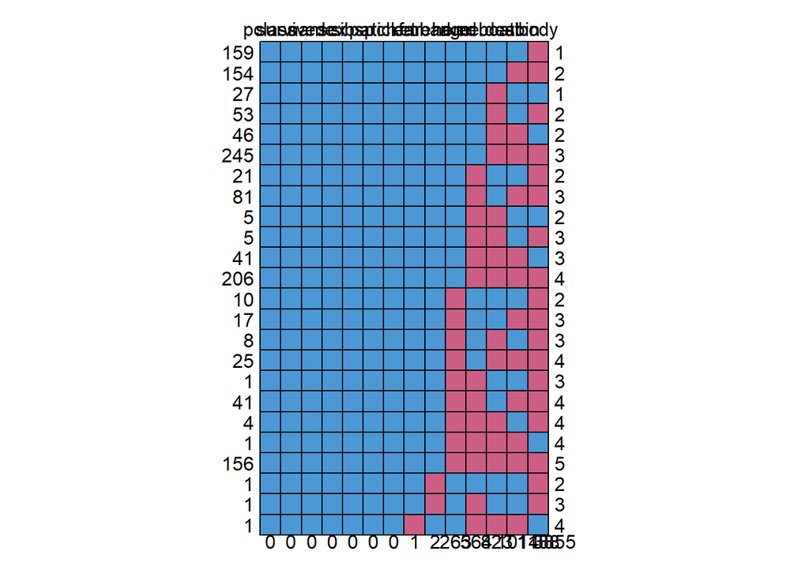

```
##     pclass survived name sex sibsp parch ticket fare embarked age
## 159      1        1    1   1     1     1      1    1        1   1
## 154      1        1    1   1     1     1      1    1        1   1
## 27       1        1    1   1     1     1      1    1        1   1
## 53       1        1    1   1     1     1      1    1        1   1
## 46       1        1    1   1     1     1      1    1        1   1
## 245      1        1    1   1     1     1      1    1        1   1
## 21       1        1    1   1     1     1      1    1        1   1
## 81       1        1    1   1     1     1      1    1        1   1
## 5        1        1    1   1     1     1      1    1        1   1
## 5        1        1    1   1     1     1      1    1        1   1
## 41       1        1    1   1     1     1      1    1        1   1
## 206      1        1    1   1     1     1      1    1        1   1
## 10       1        1    1   1     1     1      1    1        1   0
## 17       1        1    1   1     1     1      1    1        1   0
```

[output cut: 37 more lines]

```r
library(VIM)
library(mice)
md.pattern(titanic3)
```

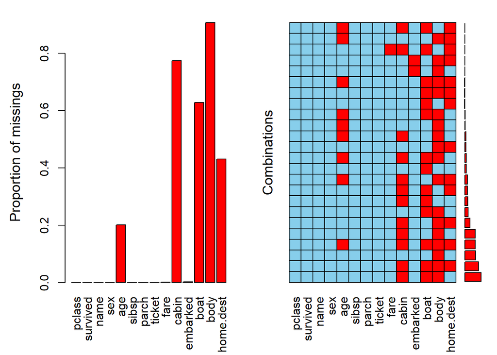

```r
aggr(titanic3)
```

5. What kind of missingness do you have for each variable that contains missing values? Give a reason and scenario as to why you believe this.

```r
# Body ID number could be missing because those who survived don't have one and many bodies were not recovered of those who didn't survive
# Cabin and boat are also hard to confirm because they are not normally memorable
```

6. Impute using mean value imputation for the age variable.
   - Graph the distributions of the age variable before and after mean value imputation. Describe what you see. What problems may arise?

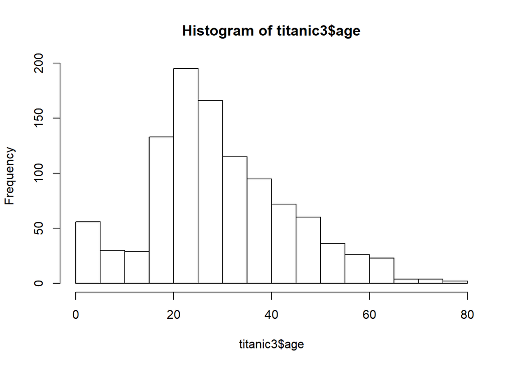

```r
library(Hmisc)
meanage_titanic = titanic3
meanage_titanic$age = impute(meanage_titanic$age, mean)
hist(titanic3$age)
```

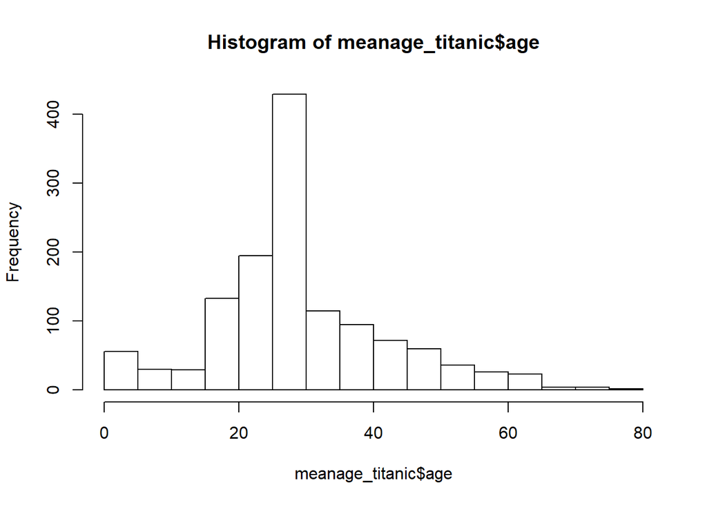

```r
hist(meanage_titanic$age)
```

```r
# There is a significant increase in people aged around 30 y/o when the mean is imputed.
```

7. Impute using simple random imputation for the age variable.
   - Graph the distributions of the age variable before and after simple random imputation. Describe what you see. What problems may arise?

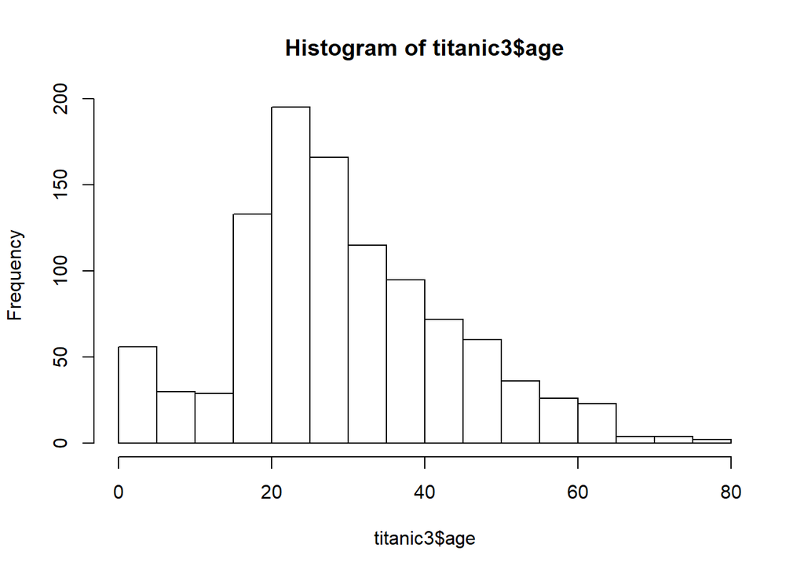

```r
set.seed(0)
srage_titanic = titanic3
srage_titanic$age = impute(srage_titanic$age, 'random')
hist(titanic3$age)
```

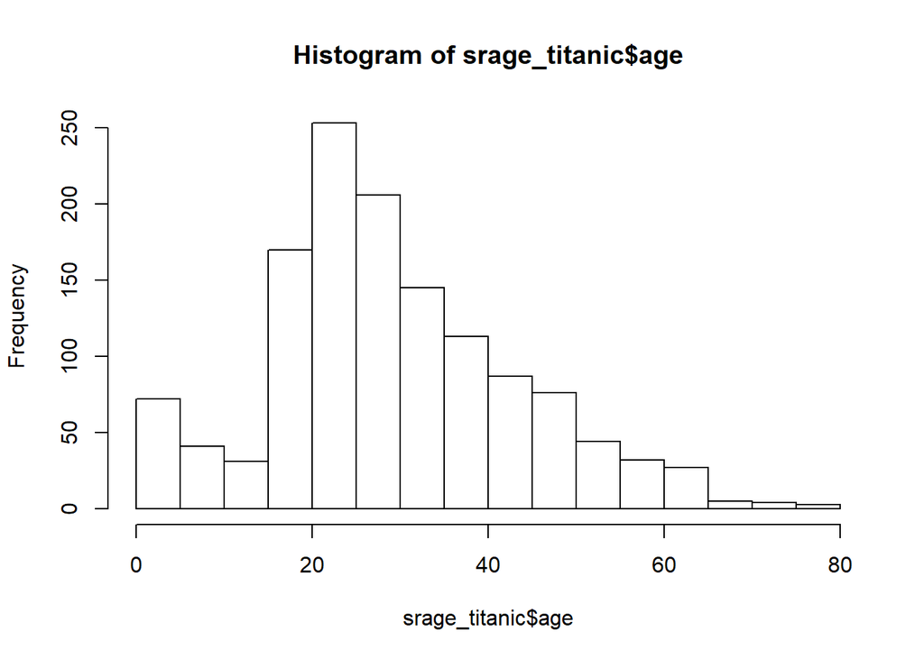

```r
hist(srage_titanic$age)
```

```r
# The graphs look very similar, however they may be a trend in the age of people who did not survive (i.e. older people may have been more likely to die)
```